# Data Mining Week 4: Classification Continued

# There are 3 common approaches we can take to handling outliers:

- Mark them: See if the outliers had an affect
- Rescale them: Log values so that they don't have as much of an affect
- Drop the data: not always a great option as we will lose observations and information

```python
# Since we are doing a Gaussian Naive Bayes algorithm, let's drop the 3 outliers we see:
surg_gbayes_df = surg_gbayes_df[(surg_gbayes_df['complication_rsi'] <= 10)]
```

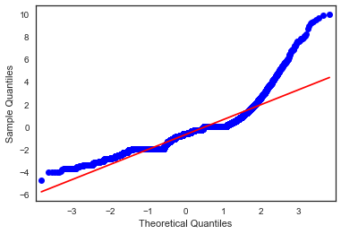

```python
# How does this affect our transformed variable?
qqplot((surg_gbayes_df['complication_rsi']), line='s')
pyplot.show()
```

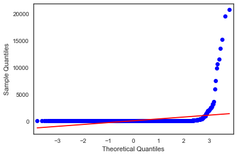

```python
# How does this affect our transformed variable?
qqplot(exp(surg_gbayes_df['complication_rsi']), line='s')
pyplot.show()
```

```python
# Still seeing some outliers - maybe eliminate more data
surg_gbayes_df = surg_gbayes_df[(surg_gbayes_df['complication_rsi'] <= 4)]
```

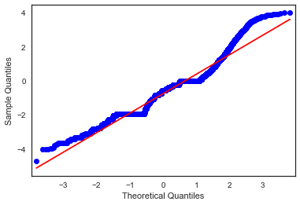

```python
qqplot((surg_gbayes_df['complication_rsi']), line='s')
pyplot.show()
```

```python
surg_gbayes_df.shape

#We still haven't lost too much data.  Let's move to the next column
```

```
(14476, 7)
```

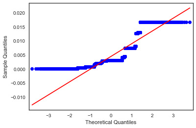

```python
# QQ plot for ccsMort30Rate
qqplot((surg_gbayes_df['ccsMort30Rate']), line='s')
pyplot.show()
```

```python
# This looks as though it may be a categorical variable.  Let's check and see if there's more evidence that would prove this:
surg_gbayes_df['ccsMort30Rate'].nunique()

# Looks that way.  We should think about dropping that column for this algorithm
```

```
20
```

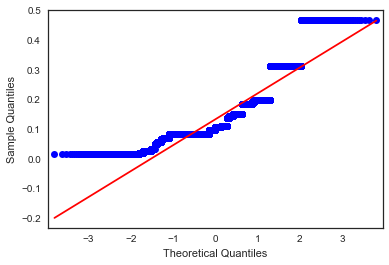

```python
# QQ plot for ccsComplicationRate
qqplot((surg_gbayes_df['ccsComplicationRate']), line='s')
pyplot.show()

# Same observations for ccsComplicationRate
```

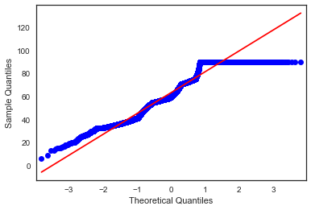

```python
# QQ plot for Age
qqplot((surg_gbayes_df['Age']), line='s')
pyplot.show()
```

```python
plt.hist(surg_gbayes_df['Age'],
         bins=25,
         alpha=0.5,
         color='purple',
         label='Age')

plt.show()
```

```
---------------------------------------------------------------------------
NameError                                 Traceback (most recent call last)
<ipython-input-51-52846fa8af31> in <module>()
----> 1 plt.hist(surg_gbayes_df['Age'],
      2          bins=25,
      3          alpha=0.5,
      4          color='purple',
      5          label='Age')

NameError: name 'plt' is not defined
```

```python
surg_gbayes_df['Age'].describe()

# Clearly, the majority of this population is fairly old.  Let's keep this as is
```

```
count    14476.000000
mean        63.169985
std         18.134093
min          6.100000
25%         51.375000
50%         59.600000
75%         74.600000
max         90.000000
Name: Age, dtype: float64
```

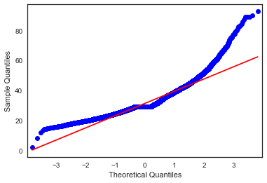

```python
# QQ plot for BMI
qqplot((surg_gbayes_df['bmi']), line='s')
pyplot.show()
```

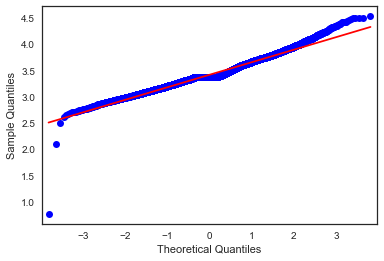

```python
# QQ plot for BMI
from numpy import log
qqplot(log(surg_gbayes_df['bmi']), line='s')
pyplot.show()

# Log transform get's us a nice normally distributed variable with only 2 outliers
```

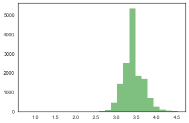

```python
import matplotlib.pyplot as plt
import numpy as np
import math

plt.hist(log(surg_gbayes_df['bmi']),
         bins=25,
         alpha=0.5,
         color='green',
         label='BMI')

plt.show()
```

```python
# Add the transformed variables to the dataframe:
surg_gbayes_df.head()
```

|  | hour | complication_rsi | ccsMort30Rate | ccsComplicationRate | Age | bmi | mort30 |
| --- | --- | --- | --- | --- | --- | --- | --- |
| 0 | 7.63 | -0.57 | 0.007424 | 0.183370 | 59.2 | 19.31 | 0 |
| 1 | 12.93 | 0.21 | 0.016673 | 0.312029 | 59.1 | 18.73 | 0 |
| 2 | 7.68 | 0.00 | 0.001962 | 0.150706 | 59.0 | 21.85 | 0 |
| 3 | 7.58 | -0.65 | 0.000000 | 0.056166 | 59.0 | 18.49 | 0 |
| 4 | 7.88 | 0.00 | 0.002764 | 0.197305 | 59.0 | 19.70 | 0 |

```python
surg_gbayes_df = surg_gbayes_df[['hour', 'complication_rsi', 'Age', 'bmi', 'mort30']]
surg_gbayes_df['bmi'] = log(surg_gbayes_df['bmi'])
```

```python
# Let's now create our Gaussian Naive Bayes model:
gnb_xvars = surg_gbayes_df[['hour', 'complication_rsi', 'Age', 'bmi']]
gnb_target = surg_gbayes_df[['mort30']]
```

```python
from sklearn.model_selection import train_test_split
x_train, x_test, y_train, y_test = train_test_split(gnb_xvars,
                                                    gnb_target,
                                                    test_size=0.2,
                                                    random_state=1)
```

```python
# Create Gaussian Naive Bayes object with prior probabilities of each class
sum(surg_gbayes_df['mort30'])/len(surg_gbayes_df['mort30'])
```

```
0.0017269964078474717
```

```python
from sklearn.naive_bayes import GaussianNB
gnb_clf = GaussianNB(priors=[0.001, 0.999])
```

```python
# Train model
gnb_model = gnb_clf.fit(x_train, y_train)
```

```python
# Predict class
train_probs = gnb_model.predict_proba(x_train)
test_probs = gnb_model.predict_proba(x_test)
```

```python
fpr, tpr, thresholds = metrics.roc_curve(y_train, train_probs[:,1])
metrics.auc(fpr, tpr)
```

```
0.85378892733564
```

```python
fpr, tpr, thresholds = metrics.roc_curve(y_test, test_probs[:,1])
metrics.auc(fpr, tpr)
```

```
0.8424766516776202
```

### This is a much better fit model. Although we sacrifice AUC on the training set, we increase AUC on the test set, which holds more value as to how the algorithm will generalize. Additionally, our train AUC is only ~0.01 higher than our test AUC, which justifies that our algorithm is likely not overfit.

# Bernoulli NB Classifier Model

```python
surg_df.head()
```

|  | bmi | Age | asa_status | baseline_cancer | baseline_charlson | baseline_cvd | baseline_dementia | baseline_diabetes | baseline_digestive | baseline_osteoart | baseline_psych | baseline_pulmonary | ahrq_ccs | ccsComplicationRate | ccsMort30Rate | complication_rsi | dow | gender | hour | month | moonphase | mort30 | mortality_rsi | race | complication |
| --- | --- | --- | --- | --- | --- | --- | --- | --- | --- | --- | --- | --- | --- | --- | --- | --- | --- | --- | --- | --- | --- | --- | --- | --- | --- |
| 0 | 19.31 | 59.2 | 1 | 1 | 0 | 0 | 0 | 0 | 0 | 0 | 0 | 0 | 19 | 0.183370 | 0.007424 | -0.57 | 3 | 0 | 7.63 | 6 | 1 | 0 | -0.43 | 1 | 0 |
| 1 | 18.73 | 59.1 | 0 | 0 | 0 | 0 | 0 | 0 | 0 | 0 | 0 | 0 | 1 | 0.312029 | 0.016673 | 0.21 | 0 | 0 | 12.93 | 0 | 1 | 0 | -0.41 | 1 | 0 |
| 2 | 21.85 | 59.0 | 0 | 0 | 0 | 0 | 0 | 0 | 0 | 0 | 0 | 0 | 6 | 0.150706 | 0.001962 | 0.00 | 2 | 0 | 7.68 | 5 | 3 | 0 | 0.08 | 1 | 0 |
| 3 | 18.49 | 59.0 | 1 | 0 | 1 | 0 | 0 | 1 | 1 | 0 | 0 | 0 | 7 | 0.056166 | 0.000000 | -0.65 | 2 | 1 | 7.58 | 4 | 3 | 0 | -0.32 | 1 | 0 |
| 4 | 19.70 | 59.0 | 1 | 0 | 0 | 0 | 0 | 0 | 0 | 0 | 0 | 0 | 11 | 0.197305 | 0.002764 | 0.00 | 0 | 0 | 7.88 | 11 | 0 | 0 | 0.00 | 1 | 0 |

```python
surg_df.nunique()

# We can see that our available variables are: baseline cancer, baseline_charlson, baseline_cvd, baseline_dementia,
# baseline_diabetes, baseline_digestive, baseline_osteoart, baseline_psych, baseline_pulmonary, dow, gender, month, moonphase,
# race, complication
```

```
bmi                    3095
Age                     672
asa_status                3
baseline_cancer           2
baseline_charlson        14
baseline_cvd              2
baseline_dementia         2
baseline_diabetes         2
baseline_digestive        2
baseline_osteoart         2
baseline_psych            2
baseline_pulmonary        2
ahrq_ccs                 22
ccsComplicationRate      22
ccsMort30Rate            20
complication_rsi        821
dow                       5
gender                    2
hour                    725
month                    12
moonphase                 4
mort30                    2
mortality_rsi           633
race                      3
complication              2
dtype: int64
```

### However, the Bernoulli clasifier only accepts categorical variables that have two levels. How can we make this work for categories such as 'dow'?

```python
surg_df_nb_bourn = surg_df[['asa_status', 'baseline_cancer', 'baseline_charlson', 'baseline_cvd', 'baseline_dementia',
                           'baseline_diabetes', 'baseline_digestive', 'baseline_osteoart', 'baseline_psych',
                            'baseline_pulmonary',
                           'dow', 'gender', 'month', 'moonphase', 'race', 'complication', 'mort30']]
```

```python
surg_df_nb_bourn.head()
```

|  | asa_status | baseline_cancer | baseline_charlson | baseline_cvd | baseline_dementia | baseline_diabetes | baseline_digestive | baseline_osteoart | baseline_psych | baseline_pulmonary | dow | gender | month | moonphase | race | complication | mort30 |
| --- | --- | --- | --- | --- | --- | --- | --- | --- | --- | --- | --- | --- | --- | --- | --- | --- | --- |
| 0 | 1 | 1 | 0 | 0 | 0 | 0 | 0 | 0 | 0 | 0 | 3 | 0 | 6 | 1 | 1 | 0 | 0 |
| 1 | 0 | 0 | 0 | 0 | 0 | 0 | 0 | 0 | 0 | 0 | 0 | 0 | 0 | 1 | 1 | 0 | 0 |
| 2 | 0 | 0 | 0 | 0 | 0 | 0 | 0 | 0 | 0 | 0 | 2 | 0 | 5 | 3 | 1 | 0 | 0 |
| 3 | 1 | 0 | 1 | 0 | 0 | 1 | 1 | 0 | 0 | 0 | 2 | 1 | 4 | 3 | 1 | 0 | 0 |
| 4 | 1 | 0 | 0 | 0 | 0 | 0 | 0 | 0 | 0 | 0 | 0 | 0 | 11 | 0 | 1 | 0 | 0 |

```python
from sklearn.preprocessing import OneHotEncoder
oh_enc = OneHotEncoder(handle_unknown='ignore')
```

```python
# One hot encoding example:
pd.get_dummies(surg_df_nb_bourn['asa_status'],prefix='asa_stat')
```

|  | asa_stat_0 | asa_stat_1 | asa_stat_2 |
| --- | --- | --- | --- |
| 0 | 0 | 1 | 0 |
| 1 | 1 | 0 | 0 |
| 2 | 1 | 0 | 0 |
| 3 | 0 | 1 | 0 |
| 4 | 0 | 1 | 0 |
| 5 | 1 | 0 | 0 |
| 6 | 1 | 0 | 0 |
| 7 | 1 | 0 | 0 |
| 8 | 0 | 1 | 0 |
| 9 | 0 | 1 | 0 |
| 10 | 0 | 1 | 0 |
| 11 | 1 | 0 | 0 |
| 12 | 1 | 0 | 0 |
| 13 | 0 | 1 | 0 |
| 14 | 1 | 0 | 0 |
| 15 | 0 | 1 | 0 |
| 16 | 1 | 0 | 0 |
| 17 | 1 | 0 | 0 |
| 18 | 1 | 0 | 0 |
| 19 | 0 | 1 | 0 |
| 20 | 1 | 0 | 0 |
| 21 | 1 | 0 | 0 |
| 22 | 0 | 1 | 0 |
| 23 | 1 | 0 | 0 |
| 24 | 1 | 0 | 0 |
| 25 | 1 | 0 | 0 |
| 26 | 1 | 0 | 0 |
| 27 | 1 | 0 | 0 |
| 28 | 0 | 1 | 0 |
| 29 | 1 | 0 | 0 |
| ... | ... | ... | ... |
| 14605 | 0 | 1 | 0 |
| 14606 | 1 | 0 | 0 |
| 14607 | 0 | 1 | 0 |
| 14608 | 1 | 0 | 0 |
| 14609 | 1 | 0 | 0 |
| 14610 | 1 | 0 | 0 |
| 14611 | 1 | 0 | 0 |
| 14612 | 0 | 1 | 0 |
| 14613 | 0 | 0 | 1 |
| 14614 | 1 | 0 | 0 |
| 14615 | 1 | 0 | 0 |
| 14616 | 0 | 1 | 0 |
| 14617 | 1 | 0 | 0 |
| 14618 | 1 | 0 | 0 |
| 14619 | 0 | 1 | 0 |
| 14620 | 1 | 0 | 0 |
| 14621 | 1 | 0 | 0 |
| 14622 | 0 | 1 | 0 |
| 14623 | 1 | 0 | 0 |
| 14624 | 1 | 0 | 0 |
| 14625 | 1 | 0 | 0 |
| 14626 | 1 | 0 | 0 |
| 14627 | 1 | 0 | 0 |
| 14628 | 1 | 0 | 0 |
| 14629 | 1 | 0 | 0 |
| 14630 | 0 | 1 | 0 |
| 14631 | 1 | 0 | 0 |
| 14632 | 0 | 1 | 0 |
| 14633 | 1 | 0 | 0 |
| 14634 | 0 | 1 | 0 |

14635 rows × 3 columns

```python
asa_stat_onehot_df = pd.get_dummies(surg_df_nb_bourn['asa_status'],prefix='asa_stat')
```

```python
# We can concatenate these dataframes as follows:
surg_df_nb_bourn = pd.concat([surg_df_nb_bourn, asa_stat_onehot_df], axis=1)
```

```python
bl_charlson_oh_df = pd.get_dummies(surg_df_nb_bourn['baseline_charlson'],prefix='baseline_charlson')
dow_oh_df = pd.get_dummies(surg_df_nb_bourn['dow'],prefix='dow')
mnth_oh_df = pd.get_dummies(surg_df_nb_bourn['month'],prefix='month')
moon_oh_df = pd.get_dummies(surg_df_nb_bourn['moonphase'],prefix='moonphase')
race_oh_df = pd.get_dummies(surg_df_nb_bourn['race'],prefix='race')
```

```python
surg_df_nb_bourn = pd.concat([surg_df_nb_bourn, dow_oh_df], axis=1)
surg_df_nb_bourn = pd.concat([surg_df_nb_bourn, mnth_oh_df], axis=1)
surg_df_nb_bourn = pd.concat([surg_df_nb_bourn, moon_oh_df], axis=1)
surg_df_nb_bourn = pd.concat([surg_df_nb_bourn, race_oh_df], axis=1)
```

```python
surg_df_nb_bourn.head()
```

|  | asa_status | baseline_cancer | baseline_charlson | baseline_cvd | baseline_dementia | baseline_diabetes | baseline_digestive | baseline_osteoart | baseline_psych | baseline_pulmonary | dow | gender | month | moonphase | race | complication | mort30 | asa_stat_0 | asa_stat_1 | asa_stat_2 | dow_0 | dow_1 | dow_2 | dow_3 | dow_4 | month_0 | month_1 | month_2 | month_3 | … |
| --- | --- | --- | --- | --- | --- | --- | --- | --- | --- | --- | --- | --- | --- | --- | --- | --- | --- | --- | --- | --- | --- | --- | --- | --- | --- | --- | --- | --- | --- | --- |
| 0 | 1 | 1 | 0 | 0 | 0 | 0 | 0 | 0 | 0 | 0 | 3 | 0 | 6 | 1 | 1 | 0 | 0 | 0 | 1 | 0 | 0 | 0 | 0 | 1 | 0 | 0 | 0 | 0 | 0 | … |
| 1 | 0 | 0 | 0 | 0 | 0 | 0 | 0 | 0 | 0 | 0 | 0 | 0 | 0 | 1 | 1 | 0 | 0 | 1 | 0 | 0 | 1 | 0 | 0 | 0 | 0 | 1 | 0 | 0 | 0 | … |
| 2 | 0 | 0 | 0 | 0 | 0 | 0 | 0 | 0 | 0 | 0 | 2 | 0 | 5 | 3 | 1 | 0 | 0 | 1 | 0 | 0 | 0 | 0 | 1 | 0 | 0 | 0 | 0 | 0 | 0 | … |
| 3 | 1 | 0 | 1 | 0 | 0 | 1 | 1 | 0 | 0 | 0 | 2 | 1 | 4 | 3 | 1 | 0 | 0 | 0 | 1 | 0 | 0 | 0 | 1 | 0 | 0 | 0 | 0 | 0 | 0 | … |
| 4 | 1 | 0 | 0 | 0 | 0 | 0 | 0 | 0 | 0 | 0 | 0 | 0 | 11 | 0 | 1 | 0 | 0 | 0 | 1 | 0 | 1 | 0 | 0 | 0 | 0 | 0 | 0 | 0 | 0 | … |

```python
surg_df_nb_bourn_vars = surg_df_nb_bourn.drop(['dow', 'month', 'moonphase', 'race', 'mort30'], axis = 1)
```

```python
surg_df_nb_bourn_target = surg_df_nb_bourn['mort30']
```

```python
# Set priors
from sklearn.naive_bayes import BernoulliNB
nb_bourn_clf = BernoulliNB(class_prior=[0.001, 0.999])
```

```python
from sklearn.model_selection import train_test_split
x_train, x_test, y_train, y_test = train_test_split(surg_df_nb_bourn_vars,
                                                    surg_df_nb_bourn_target,
                                                    test_size=0.2,
                                                    random_state=1)
```

```python
# Train model
nb_bourn_model = nb_bourn_clf.fit(x_train, y_train)
```

```python
# Predict class
train_probs = nb_bourn_model.predict_proba(x_train)
test_probs = nb_bourn_model.predict_proba(x_test)
```

```python
fpr, tpr, thresholds = metrics.roc_curve(y_train, train_probs[:,1])
metrics.auc(fpr, tpr)
```

```
0.8331930415263749
```

```python
fpr, tpr, thresholds = metrics.roc_curve(y_test, test_probs[:,1])
metrics.auc(fpr, tpr)
```

```
0.8567260065715266
```

##### Interesting that our test set outperforms our train set. Is it underfit? Or does our target class not have matching proportions between the train and test sets?

```python
sum(y_train)/len(y_train)
```

```
0.0037581141100102495
```

```python
sum(y_test)/len(y_test)
```

```
0.004783054321831227
```

## We can also use Naive Bayes classifiers on multinomial outcome datasets

#### We will use the red wine quality classification dataset from Kaggle for our multinomial exercise:

```python
wine_df = pd.read_csv('wineQualityReds.csv')
wine_df = wine_df.drop(['Unnamed: 0'], axis=1)
```

```python
wine_df.head()
```

|  | fixed.acidity | volatile.acidity | citric.acid | residual.sugar | chlorides | free.sulfur.dioxide | total.sulfur.dioxide | density | pH | sulphates | alcohol | quality |
| --- | --- | --- | --- | --- | --- | --- | --- | --- | --- | --- | --- | --- |
| 0 | 7.4 | 0.70 | 0.00 | 1.9 | 0.076 | 11.0 | 34.0 | 0.9978 | 3.51 | 0.56 | 9.4 | 5 |
| 1 | 7.8 | 0.88 | 0.00 | 2.6 | 0.098 | 25.0 | 67.0 | 0.9968 | 3.20 | 0.68 | 9.8 | 5 |
| 2 | 7.8 | 0.76 | 0.04 | 2.3 | 0.092 | 15.0 | 54.0 | 0.9970 | 3.26 | 0.65 | 9.8 | 5 |
| 3 | 11.2 | 0.28 | 0.56 | 1.9 | 0.075 | 17.0 | 60.0 | 0.9980 | 3.16 | 0.58 | 9.8 | 6 |
| 4 | 7.4 | 0.70 | 0.00 | 1.9 | 0.076 | 11.0 | 34.0 | 0.9978 | 3.51 | 0.56 | 9.4 | 5 |

```python
wine_df.describe()
```

|  | fixed.acidity | volatile.acidity | citric.acid | residual.sugar | chlorides | free.sulfur.dioxide | total.sulfur.dioxide | density | pH | sulphates | alcohol | quality |
| --- | --- | --- | --- | --- | --- | --- | --- | --- | --- | --- | --- | --- |
| count | 1599.000000 | 1599.000000 | 1599.000000 | 1599.000000 | 1599.000000 | 1599.000000 | 1599.000000 | 1599.000000 | 1599.000000 | 1599.000000 | 1599.000000 | 1599.000000 |
| mean | 8.319637 | 0.527821 | 0.270976 | 2.538806 | 0.087467 | 15.874922 | 46.467792 | 0.996747 | 3.311113 | 0.658149 | 10.422983 | 5.636023 |
| std | 1.741096 | 0.179060 | 0.194801 | 1.409928 | 0.047065 | 10.460157 | 32.895324 | 0.001887 | 0.154386 | 0.169507 | 1.065668 | 0.807569 |
| min | 4.600000 | 0.120000 | 0.000000 | 0.900000 | 0.012000 | 1.000000 | 6.000000 | 0.990070 | 2.740000 | 0.330000 | 8.400000 | 3.000000 |
| 25% | 7.100000 | 0.390000 | 0.090000 | 1.900000 | 0.070000 | 7.000000 | 22.000000 | 0.995600 | 3.210000 | 0.550000 | 9.500000 | 5.000000 |
| 50% | 7.900000 | 0.520000 | 0.260000 | 2.200000 | 0.079000 | 14.000000 | 38.000000 | 0.996750 | 3.310000 | 0.620000 | 10.200000 | 6.000000 |
| 75% | 9.200000 | 0.640000 | 0.420000 | 2.600000 | 0.090000 | 21.000000 | 62.000000 | 0.997835 | 3.400000 | 0.730000 | 11.100000 | 6.000000 |
| max | 15.900000 | 1.580000 | 1.000000 | 15.500000 | 0.611000 | 72.000000 | 289.000000 | 1.003690 | 4.010000 | 2.000000 | 14.900000 | 8.000000 |

```python
wine_df['quality'].nunique()
```

```
6
```

```python
pd.crosstab(wine_df['quality'], wine_df['quality'],
            rownames=['Quality'], colnames=['Wine'], margins=True)
```

| Wine Quality | 3 | 4 | 5 | 6 | 7 | 8 | All |
| --- | --- | --- | --- | --- | --- | --- | --- |
| 3 | 10 | 0 | 0 | 0 | 0 | 0 | 10 |
| 4 | 0 | 53 | 0 | 0 | 0 | 0 | 53 |
| 5 | 0 | 0 | 681 | 0 | 0 | 0 | 681 |
| 6 | 0 | 0 | 0 | 638 | 0 | 0 | 638 |
| 7 | 0 | 0 | 0 | 0 | 199 | 0 | 199 |
| 8 | 0 | 0 | 0 | 0 | 0 | 18 | 18 |
| All | 10 | 53 | 681 | 638 | 199 | 18 | 1599 |

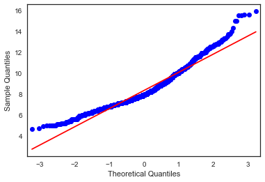

```python
# We again want to check the normality of the continuous variables as Naive Bayes assumes normal distribution:
qqplot((wine_df['fixed.acidity']), line='s')
pyplot.show()
```

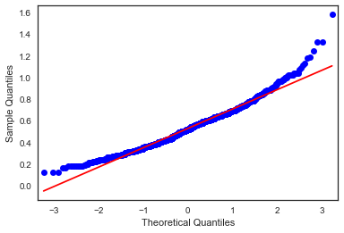

```python
qqplot((wine_df['volatile.acidity']), line='s')
pyplot.show()
```

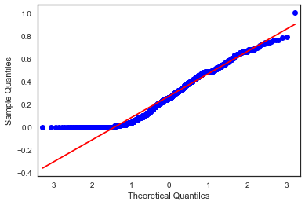

```python
qqplot((wine_df['citric.acid']), line='s')
pyplot.show()
```

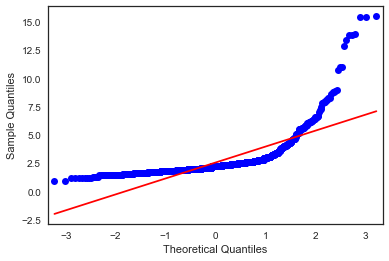

```python
qqplot((wine_df['residual.sugar']), line='s')
pyplot.show()
```

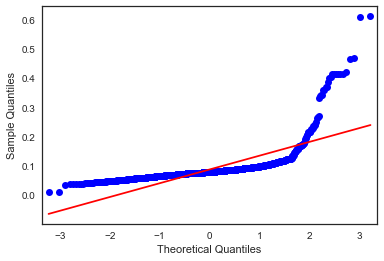

```python
qqplot((wine_df['chlorides']), line='s')
pyplot.show()
```

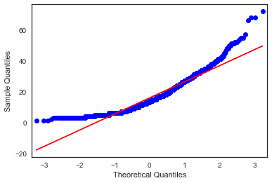

```python
qqplot((wine_df['free.sulfur.dioxide']), line='s')
pyplot.show()
```

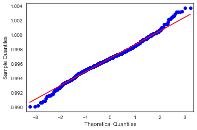

```python
qqplot((wine_df['density']), line='s')
pyplot.show()
```

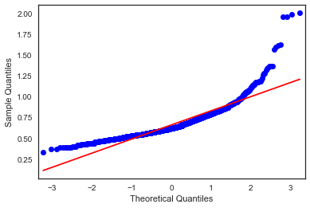

```python
qqplot((wine_df['sulphates']), line='s')
pyplot.show()
```

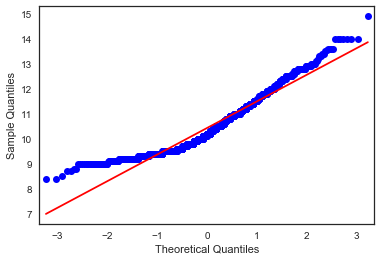

```python
qqplot((wine_df['alcohol']), line='s')
pyplot.show()
```

```python
from sklearn.naive_bayes import MultinomialNB
```

```python
x_vars = wine_df.drop(['quality'], axis=1)
```

```python
x_train, x_test, y_train, y_test = train_test_split(x_vars,
                                                    wine_df[['quality']],
                                                    test_size=0.2,
                                                    random_state=1)
```

```python
multinb_clf = MultinomialNB(#class_prior = [0.006, 0.03, 0.42, 0.39, 0.12, 0.1]
                           )
```

```python
model = multinb_clf.fit(x_train, y_train)
```

```python
y_pred_df = y_test
```

```python
y_pred_df['CLASS_PREDS'] = model.predict(x_test)
```

```python
pd.crosstab(y_pred_df['quality'], y_pred_df['CLASS_PREDS'],
            rownames=['True'], colnames=['Predicted'], margins=True)
```

| Predicted True | 3 | 5 | 6 | 7 | All |
| --- | --- | --- | --- | --- | --- |
| 3 | 0 | 0 | 1 | 0 | 1 |
| 4 | 2 | 3 | 5 | 3 | 13 |
| 5 | 6 | 72 | 42 | 20 | 140 |
| 6 | 3 | 43 | 51 | 37 | 134 |
| 7 | 3 | 4 | 11 | 12 | 30 |
| 8 | 0 | 0 | 1 | 1 | 2 |
| All | 14 | 122 | 111 | 73 | 320 |

# How can we evaluate this matrix??

```python
# We can also predict probabilities with our new model:
mnb_df = pd.DataFrame(model.predict_proba(x_test))
mnb_df.columns = ['prob' + str(col) for col in mnb_df.columns]
mnb_df.head()
```

|  | prob0 | prob1 | prob2 | prob3 | prob4 | prob5 |
| --- | --- | --- | --- | --- | --- | --- |
| 0 | 8.532451e-04 | 0.064400 | 0.333928 | 0.465097 | 0.123428 | 0.012295 |
| 1 | 7.324208e-08 | 0.001137 | 0.950907 | 0.047144 | 0.000763 | 0.000049 |
| 2 | 3.280948e-01 | 0.055750 | 0.001063 | 0.094016 | 0.466937 | 0.054139 |
| 3 | 2.198168e-06 | 0.001189 | 0.559992 | 0.423279 | 0.014735 | 0.000802 |
| 4 | 1.978375e-02 | 0.035698 | 0.013142 | 0.424550 | 0.457522 | 0.049305 |

```python
from sklearn.metrics import accuracy_score
from sklearn.metrics import confusion_matrix

confusion_matrix(y_pred_df['quality'], y_pred_df['CLASS_PREDS'])
```

```
array([[ 0,  0,  0,  1,  0,  0],
       [ 2,  0,  3,  5,  3,  0],
       [ 6,  0, 72, 42, 20,  0],
       [ 3,  0, 43, 51, 37,  0],
       [ 3,  0,  4, 11, 12,  0],
       [ 0,  0,  0,  1,  1,  0]], dtype=int64)
```

```python
accuracy_score(y_pred_df['quality'],  y_pred_df['CLASS_PREDS'])
```

```
0.421875
```

```python
y_pred_df['TP3'] = np.where(y_pred_df['quality'] == 3, 1, 0)
y_pred_df['TP4'] = np.where(y_pred_df['quality'] == 4, 1, 0)
y_pred_df['TP5'] = np.where(y_pred_df['quality'] == 5, 1, 0)
y_pred_df['TP6'] = np.where(y_pred_df['quality'] == 6, 1, 0)
y_pred_df['TP7'] = np.where(y_pred_df['quality'] == 7, 1, 0)
y_pred_df['TP8'] = np.where(y_pred_df['quality'] == 8, 1, 0)
```

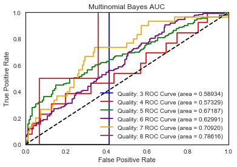

```python
# We can visualize these ROC curves with matplotlib
import matplotlib.pyplot as plt
from sklearn.metrics import confusion_matrix, roc_curve, roc_auc_score

plt.plot(roc_curve(y_pred_df['TP3'], mnb_df['prob0'])[0],roc_curve(y_pred_df['TP3'], mnb_df['prob0'])[1],
         color = 'blue', label='Quality: 3 ROC Curve (area = %0.5f)' % roc_auc_score(y_pred_df['TP3'], mnb_df['prob0']))

plt.plot(roc_curve(y_pred_df['TP4'], mnb_df['prob1'])[0],roc_curve(y_pred_df['TP4'], mnb_df['prob1'])[1],
         color = 'red', label='Quality: 4 ROC Curve (area = %0.5f)' % roc_auc_score(y_pred_df['TP4'], mnb_df['prob1']))

plt.plot(roc_curve(y_pred_df['TP5'], mnb_df['prob2'])[0],roc_curve(y_pred_df['TP5'], mnb_df['prob2'])[1],
         color = 'green', label='Quality: 5 ROC Curve (area = %0.5f)' % roc_auc_score(y_pred_df['TP5'], mnb_df['prob2']))

plt.plot(roc_curve(y_pred_df['TP6'], mnb_df['prob3'])[0],roc_curve(y_pred_df['TP6'], mnb_df['prob3'])[1],
         color = 'purple', label='Quality: 6 ROC Curve (area = %0.5f)' % roc_auc_score(y_pred_df['TP6'], mnb_df['prob3']))

plt.plot(roc_curve(y_pred_df['TP7'], mnb_df['prob4'])[0],roc_curve(y_pred_df['TP7'], mnb_df['prob4'])[1],
         color = 'orange', label='Quality: 7 ROC Curve (area = %0.5f)' % roc_auc_score(y_pred_df['TP7'], mnb_df['prob4']))

plt.plot(roc_curve(y_pred_df['TP8'], mnb_df['prob5'])[0],roc_curve(y_pred_df['TP8'], mnb_df['prob5'])[1],
         color = 'brown', label='Quality: 8 ROC Curve (area = %0.5f)' % roc_auc_score(y_pred_df['TP8'], mnb_df['prob5']))



plt.plot([0, 2], [0, 2], color='black', linestyle='--')
plt.xlim([0.0, 1.0])
plt.ylim([0.0, 1.0])
plt.xlabel('False Positive Rate')
plt.ylabel('True Positive Rate')
plt.title('Multinomial Bayes AUC')
plt.legend()
plt.show()
sns.set(style='white', rc={'figure.figsize':(10,10)})
```

```python
# Let's set how multinomial logistic regression works in comparison:
from sklearn.linear_model import LogisticRegression
mnlr = LogisticRegression(random_state=0, multi_class='multinomial', solver='newton-cg')
```

```python
mnlr_model = mnlr.fit(x_train, y_train)
```

```python
y_test_mnlr = y_test
y_test_mnlr.head()
```

|  | quality | CLASS_PREDS | TP3 | TP4 | TP5 | TP6 | TP7 | TP8 |
| --- | --- | --- | --- | --- | --- | --- | --- | --- |
| 75 | 5 | 6 | 0 | 0 | 1 | 0 | 0 | 0 |
| 1283 | 6 | 5 | 0 | 0 | 0 | 1 | 0 | 0 |
| 408 | 6 | 7 | 0 | 0 | 0 | 1 | 0 | 0 |
| 1281 | 6 | 5 | 0 | 0 | 0 | 1 | 0 | 0 |
| 1118 | 6 | 7 | 0 | 0 | 0 | 1 | 0 | 0 |

```python
y_test_mnlr['MNLR_CLASS_PREDS'] = mnlr_model.predict(x_test)
```

```python
accuracy_score(y_test_mnlr['quality'],  y_test_mnlr['MNLR_CLASS_PREDS'])
```

```
0.615625
```

```python
# Would this improve even more if we used lasso/ridge?
mnlr = LogisticRegression(random_state=0, multi_class='multinomial', solver='newton-cg', penalty = 'l2',
                         C = 2, max_iter = 100)
```

```python
mnlr_model = mnlr.fit(x_train, y_train)
```

```python
y_test_mnlr['MNLR_CLASS_PREDS'] = mnlr_model.predict(x_test)
```

```python
accuracy_score(y_test_mnlr['quality'],  y_test_mnlr['MNLR_CLASS_PREDS'])

# We could continue to do gridsearch on your alpha values to find a better model.  For the sake of time, we will stop here.
```

```
0.6125
```

# Random Forest Model: Classification

```python
# We will use a hospital readmissions dataset available on Kaggle:
hosp_returns_df = pd.read_csv('hospital-readmissions-orig.csv')
```

```python
hosp_returns_df.shape
```

```
(59557, 18)
```

```python
hosp_returns_df.head()
```

|  | race | gender | age | admission_type_id | discharge_disposition_id | admission_source_id | time_in_hospital | num_lab_procedures | num_procedures | num_medications | number_outpatient | number_emergency | number_inpatient | diag_1 | diag_2 | diag_3 | number_diagnoses | readmitted |
| --- | --- | --- | --- | --- | --- | --- | --- | --- | --- | --- | --- | --- | --- | --- | --- | --- | --- | --- |
| 0 | 2 | 1 | 3 | 1 | 1 | 7 | 2 | 44 | 1 | 16 | 0 | 0 | 0 | 8.0 | 250.43 | 403.0 | 7 | 0 |
| 1 | 2 | 1 | 4 | 1 | 1 | 7 | 1 | 51 | 0 | 8 | 0 | 0 | 0 | 197.0 | 157.00 | 250.0 | 5 | 0 |
| 2 | 2 | 0 | 8 | 2 | 1 | 4 | 13 | 68 | 2 | 28 | 0 | 0 | 0 | 398.0 | 427.00 | 38.0 | 8 | 0 |
| 3 | 2 | 0 | 9 | 3 | 3 | 4 | 12 | 33 | 3 | 18 | 0 | 0 | 0 | 434.0 | 198.00 | 486.0 | 8 | 0 |
| 4 | 0 | 1 | 6 | 2 | 1 | 4 | 7 | 62 | 0 | 11 | 0 | 0 | 0 | 157.0 | 288.00 | 197.0 | 7 | 1 |

```python
from sklearn.ensemble import RandomForestClassifier
# Let's first take a look at our proportion of readmissions vs. non-readmissions:
print(sum(hosp_returns_df['readmitted']), ', ', sum(hosp_returns_df['readmitted'])/len(hosp_returns_df['readmitted']), '%')
```

```
10261 ,  0.17228873180314658 %
```

```python
x_vars_rf = hosp_returns_df.drop(['readmitted'], axis=1)
```

```python
hosp_returns_df.describe()
```

|  | race | gender | age | admission_type_id | discharge_disposition_id | admission_source_id | time_in_hospital | num_lab_procedures | num_procedures | num_medications | number_outpatient | number_emergency | number_inpatient | diag_1 | diag_2 | diag_3 | number_diagnoses | readmitted |
| --- | --- | --- | --- | --- | --- | --- | --- | --- | --- | --- | --- | --- | --- | --- | --- | --- | --- | --- |
| count | 59557.000000 | 59557.000000 | 59557.000000 | 59557.000000 | 59557.000000 | 59557.000000 | 59557.000000 | 59557.000000 | 59557.000000 | 59557.000000 | 59557.000000 | 59557.000000 | 59557.000000 | 59557.000000 | 59557.000000 | 59557.000000 | 59557.000000 | 59557.000000 |
| mean | 1.662676 | 0.467569 | 6.125795 | 2.004735 | 3.915140 | 5.720352 | 4.381013 | 43.273251 | 1.419145 | 16.109592 | 0.302870 | 0.153970 | 0.518478 | 490.566636 | 439.377272 | 416.918625 | 7.414275 | 0.172289 |
| std | 0.862296 | 0.499019 | 1.567977 | 1.422788 | 5.477445 | 4.065662 | 2.974803 | 19.791889 | 1.749307 | 8.460186 | 1.093617 | 0.750446 | 1.150570 | 204.323718 | 179.455006 | 179.114003 | 1.878637 | 0.377634 |
| min | 0.000000 | 0.000000 | 0.000000 | 1.000000 | 1.000000 | 1.000000 | 1.000000 | 1.000000 | 0.000000 | 1.000000 | 0.000000 | 0.000000 | 0.000000 | 3.000000 | 8.000000 | 5.000000 | 3.000000 | 0.000000 |
| 25% | 2.000000 | 0.000000 | 5.000000 | 1.000000 | 1.000000 | 1.000000 | 2.000000 | 31.000000 | 0.000000 | 10.000000 | 0.000000 | 0.000000 | 0.000000 | 410.000000 | 276.000000 | 272.000000 | 6.000000 | 0.000000 |
| 50% | 2.000000 | 0.000000 | 6.000000 | 1.000000 | 1.000000 | 7.000000 | 4.000000 | 44.000000 | 1.000000 | 15.000000 | 0.000000 | 0.000000 | 0.000000 | 436.000000 | 425.000000 | 402.000000 | 8.000000 | 0.000000 |
| 75% | 2.000000 | 1.000000 | 7.000000 | 3.000000 | 4.000000 | 7.000000 | 6.000000 | 57.000000 | 2.000000 | 20.000000 | 0.000000 | 0.000000 | 1.000000 | 596.000000 | 535.000000 | 496.000000 | 9.000000 | 0.000000 |
| max | 4.000000 | 2.000000 | 9.000000 | 8.000000 | 28.000000 | 25.000000 | 14.000000 | 132.000000 | 6.000000 | 81.000000 | 40.000000 | 64.000000 | 21.000000 | 999.000000 | 999.000000 | 999.000000 | 16.000000 | 1.000000 |

```python
hosp_returns_df.nunique()
```

```
race                          5
gender                        3
age                          10
admission_type_id             8
discharge_disposition_id     26
admission_source_id          16
time_in_hospital             14
num_lab_procedures          116
num_procedures                7
num_medications              75
number_outpatient            30
number_emergency             26
number_inpatient             18
diag_1                      655
diag_2                      599
diag_3                      633
number_diagnoses             14
readmitted                    2
dtype: int64
```

```python
rf_clf = RandomForestClassifier(random_state = 0, n_jobs = -1)
```

```python
from sklearn.model_selection import train_test_split
x_train, x_test, y_train, y_test = train_test_split(x_vars_rf,
                                                    hosp_returns_df['readmitted'],
                                                    test_size=0.2,
                                                    random_state=1)
```

```python
rf_clf_model = rf_clf.fit(x_train, y_train)
```

```python
rf_train_probs = rf_clf_model.predict_proba(x_train)
rf_test_probs = rf_clf_model.predict_proba(x_test)
```

```python
rf_train_prob_cols = ['class', 'proba']
```

```python
rf_preds_train = pd.DataFrame(rf_train_probs, columns=rf_train_prob_cols)
rf_preds_test = pd.DataFrame(rf_test_probs, columns=rf_train_prob_cols)
```

```python
fpr, tpr, thresholds = metrics.roc_curve(y_train, rf_preds_train['proba'])
metrics.auc(fpr, tpr)
```

```
0.9994079156795809
```

```python
fpr, tpr, thresholds = metrics.roc_curve(y_test, rf_preds_test['proba'])
metrics.auc(fpr, tpr)
```

```
0.6525532123630391
```

```python
# Very overfit.  But, with random forest ability to ensemble and tune hyperparameters, we can fix this problem:
rf_clf = RandomForestClassifier(random_state = 0, n_jobs = -1, criterion = 'gini', max_features = 5, max_depth = 11,
                               #min_samples_split = ???,
                               #min_samples_leaf = ???,
                               #min_weight_fraction = ???,
                               #min_impurity_decrease = ???,
                               #class_weight = ???
                               )
```

```python
rf_clf_model = rf_clf.fit(x_train, y_train)
```

```python
rf_train_probs = rf_clf_model.predict_proba(x_train)
rf_test_probs = rf_clf_model.predict_proba(x_test)
```

```python
rf_train_prob_cols = ['class', 'proba']
```

```python
rf_preds_train = pd.DataFrame(rf_train_probs, columns=rf_train_prob_cols)
rf_preds_test = pd.DataFrame(rf_test_probs, columns=rf_train_prob_cols)
```

```python
fpr, tpr, thresholds = metrics.roc_curve(y_train, rf_preds_train['proba'])
metrics.auc(fpr, tpr)
```

```
0.8096126413993756
```

```python
fpr, tpr, thresholds = metrics.roc_curve(y_test, rf_preds_test['proba'])
metrics.auc(fpr, tpr)
```

```
0.7145073797154936
```

# Random Forest Regressor

```python
chi_taxi_df = pd.read_csv('chicago_taxi_trips_2016_12.csv')
```

```python
chi_taxi_df.shape
```

```
(1245712, 20)
```

```python
chi_taxi_df.head()
```

|  | taxi_id | trip_start_timestamp | trip_end_timestamp | trip_seconds | trip_miles | pickup_census_tract | dropoff_census_tract | pickup_community_area | dropoff_community_area | fare | tips | tolls | extras | trip_total | payment_type | company | pickup_latitude | pickup_longitude | dropoff_latitude | dropoff_longitude |
| --- | --- | --- | --- | --- | --- | --- | --- | --- | --- | --- | --- | --- | --- | --- | --- | --- | --- | --- | --- | --- |
| 0 | 5240.0 | 2016-12-15 23:45:00 | 2016-12-16 00:00:00 | 900.0 | 2.5 | NaN | 307.0 | 8.0 | 32.0 | 10.75 | 2.45 | 0.0 | 1.0 | 14.70 | Credit Card | NaN | 754.0 | 410.0 | 64.0 | 231.0 |
| 1 | 1215.0 | 2016-12-12 07:15:00 | 2016-12-12 07:15:00 | 240.0 | 0.4 | NaN | 40.0 | 28.0 | 28.0 | 5.00 | 3.00 | 0.0 | 1.0 | 9.50 | Credit Card | NaN | 395.0 | 408.0 | 395.0 | 408.0 |
| 2 | 3673.0 | 2016-12-16 16:30:00 | 2016-12-16 17:00:00 | 2400.0 | 10.7 | NaN | NaN | 32.0 | NaN | 31.00 | 0.00 | 0.0 | 0.0 | 31.00 | Cash | NaN | 385.0 | 478.0 | NaN | NaN |
| 3 | 5400.0 | 2016-12-16 08:45:00 | 2016-12-16 09:00:00 | 300.0 | 0.0 | NaN | 787.0 | 8.0 | 8.0 | 5.25 | 2.00 | 0.0 | 0.0 | 7.25 | Credit Card | 101.0 | 688.0 | 206.0 | 161.0 | 649.0 |
| 4 | 1257.0 | 2016-12-3 18:45:00 | 2016-12-3 18:45:00 | 360.0 | 0.3 | NaN | 534.0 | 7.0 | 8.0 | 5.00 | 0.00 | 0.0 | 0.0 | 5.00 | Cash | 3.0 | 618.0 | 407.0 | 454.0 | 453.0 |

```python
chi_taxi_df = chi_taxi_df.dropna(subset=['fare'])
```

```python
chi_taxi_df.describe()
```

|  | taxi_id | trip_seconds | trip_miles | pickup_census_tract | dropoff_census_tract | pickup_community_area | dropoff_community_area | fare | tips | tolls | extras | trip_total | company | pickup_latitude | pickup_longitude | dropoff_latitude | dropoff_longitude |
| --- | --- | --- | --- | --- | --- | --- | --- | --- | --- | --- | --- | --- | --- | --- | --- | --- | --- |
| count | 1.245072e+06 | 1.245593e+06 | 1.245687e+06 | 0.0 | 787226.000000 | 1.131340e+06 | 1.111880e+06 | 1.245689e+06 | 1.245689e+06 | 1.245689e+06 | 1.245689e+06 | 1.245689e+06 | 671304.000000 | 1.131347e+06 | 1.131347e+06 | 1.113229e+06 | 1.113229e+06 |
| mean | 4.361871e+03 | 7.565637e+02 | 2.722646e+00 | NaN | 514.283230 | 2.281090e+01 | 2.106795e+01 | 1.240251e+01 | 1.376216e+00 | 4.248508e-03 | 9.401077e-01 | 1.481602e+01 | 83.407668 | 3.861336e+02 | 4.409323e+02 | 3.964374e+02 | 4.388252e+02 |
| std | 2.511684e+03 | 1.090563e+03 | 4.914543e+00 | NaN | 357.143149 | 1.879819e+01 | 1.694034e+01 | 2.153353e+01 | 2.654190e+00 | 1.260149e+00 | 1.523253e+01 | 2.784119e+01 | 38.243615 | 2.540736e+02 | 1.890505e+02 | 2.560482e+02 | 1.987687e+02 |
| min | 0.000000e+00 | 0.000000e+00 | 0.000000e+00 | NaN | 2.000000 | 1.000000e+00 | 1.000000e+00 | 0.000000e+00 | 0.000000e+00 | 0.000000e+00 | 0.000000e+00 | 0.000000e+00 | 2.000000 | 5.000000e+00 | 1.000000e+00 | 0.000000e+00 | 1.000000e+00 |
| 25% | 2.229000e+03 | 3.600000e+02 | 4.000000e-01 | NaN | 225.000000 | 8.000000e+00 | 8.000000e+00 | 6.000000e+00 | 0.000000e+00 | 0.000000e+00 | 0.000000e+00 | 7.000000e+00 | 82.000000 | 1.700000e+02 | 3.460000e+02 | 1.700000e+02 | 2.700000e+02 |
| 50% | 4.316000e+03 | 5.400000e+02 | 1.100000e+00 | NaN | 504.000000 | 2.400000e+01 | 1.600000e+01 | 8.000000e+00 | 0.000000e+00 | 0.000000e+00 | 0.000000e+00 | 9.500000e+00 | 101.000000 | 3.950000e+02 | 4.780000e+02 | 4.110000e+02 | 4.780000e+02 |
| 75% | 6.524000e+03 | 9.000000e+02 | 2.400000e+00 | NaN | 807.000000 | 3.200000e+01 | 3.200000e+01 | 1.225000e+01 | 2.000000e+00 | 0.000000e+00 | 1.000000e+00 | 1.425000e+01 | 107.000000 | 6.040000e+02 | 6.100000e+02 | 6.810000e+02 | 6.100000e+02 |
| max | 8.760000e+03 | 8.634000e+04 | 9.000000e+02 | NaN | 1140.000000 | 7.700000e+01 | 7.700000e+01 | 9.026310e+03 | 4.220000e+02 | 8.000000e+02 | 6.666660e+03 | 9.026310e+03 | 118.000000 | 7.840000e+02 | 7.850000e+02 | 7.840000e+02 | 7.850000e+02 |

```python
chi_taxi_df.nunique()
```

```
taxi_id                   4550
trip_start_timestamp      2976
trip_end_timestamp        2983
trip_seconds              3855
trip_miles                2868
pickup_census_tract          0
dropoff_census_tract       421
pickup_community_area       77
dropoff_community_area      77
fare                      1247
tips                      1516
tolls                       74
extras                     586
trip_total                4578
payment_type                 8
company                     50
pickup_latitude            320
pickup_longitude           320
dropoff_latitude           420
dropoff_longitude          420
dtype: int64
```

```python
x_vars = chi_taxi_df[['trip_seconds', 'trip_miles', 'dropoff_census_tract', 'pickup_community_area',
                     'dropoff_community_area', 'tips', 'tolls', 'extras', 'payment_type', 'company']]

target = chi_taxi_df[['fare']]
```

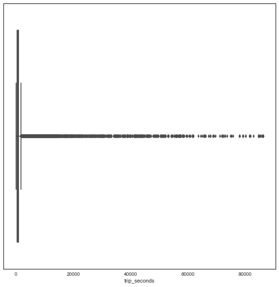

```python
sns.boxplot(x = x_vars['trip_seconds'])
```

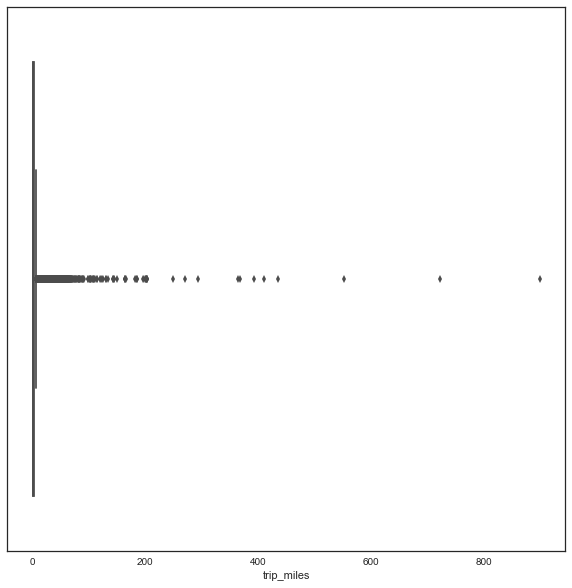

```python
sns.boxplot(x = x_vars['trip_miles'])
```

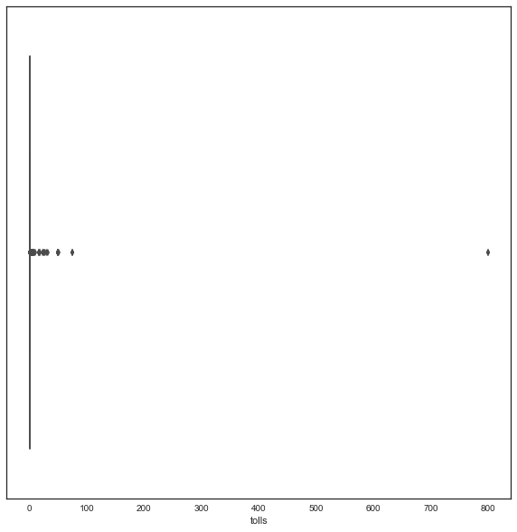

```python
sns.boxplot(x = x_vars['tolls'])
```

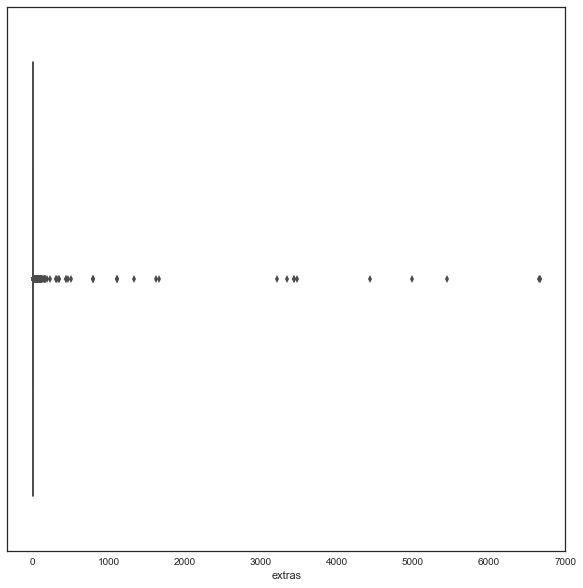

```python
sns.boxplot(x = x_vars['extras'])
```

```python
payment_type_one_hot = pd.get_dummies(x_vars, columns = ['payment_type'], prefix = 'pay_type')
```

```python
payment_type_one_hot.head()
```

|  | trip_seconds | trip_miles | dropoff_census_tract | pickup_community_area | dropoff_community_area | tips | tolls | extras | company | pay_type_Cash | pay_type_Credit Card | pay_type_Dispute | pay_type_No Charge | pay_type_Pcard | pay_type_Prcard | pay_type_Unknown | pay_type_Way2ride |
| --- | --- | --- | --- | --- | --- | --- | --- | --- | --- | --- | --- | --- | --- | --- | --- | --- | --- |
| 0 | 900.0 | 2.5 | 307.0 | 8.0 | 32.0 | 2.45 | 0.0 | 1.0 | NaN | 0 | 1 | 0 | 0 | 0 | 0 | 0 | 0 |
| 1 | 240.0 | 0.4 | 40.0 | 28.0 | 28.0 | 3.00 | 0.0 | 1.0 | NaN | 0 | 1 | 0 | 0 | 0 | 0 | 0 | 0 |
| 2 | 2400.0 | 10.7 | NaN | 32.0 | NaN | 0.00 | 0.0 | 0.0 | NaN | 1 | 0 | 0 | 0 | 0 | 0 | 0 | 0 |
| 3 | 300.0 | 0.0 | 787.0 | 8.0 | 8.0 | 2.00 | 0.0 | 0.0 | 101.0 | 0 | 1 | 0 | 0 | 0 | 0 | 0 | 0 |
| 4 | 360.0 | 0.3 | 534.0 | 7.0 | 8.0 | 0.00 | 0.0 | 0.0 | 3.0 | 1 | 0 | 0 | 0 | 0 | 0 | 0 | 0 |

```python
x_vars = payment_type_one_hot
```

```python
x_vars = x_vars.fillna(0)
```

```python
x_vars.describe()
```

|  | trip_seconds | trip_miles | dropoff_census_tract | pickup_community_area | dropoff_community_area | tips | tolls | extras | company | pay_type_Cash | pay_type_Credit Card | pay_type_Dispute | pay_type_No Charge | pay_type_Pcard | pay_type_Prcard | pay_type_Unknown | pay_type_Way2ride |
| --- | --- | --- | --- | --- | --- | --- | --- | --- | --- | --- | --- | --- | --- | --- | --- | --- | --- |
| count | 1.245689e+06 | 1.245689e+06 | 1.245689e+06 | 1.245689e+06 | 1.245689e+06 | 1.245689e+06 | 1.245689e+06 | 1.245689e+06 | 1.245689e+06 | 1.245689e+06 | 1.245689e+06 | 1.245689e+06 | 1.245689e+06 | 1.245689e+06 | 1.245689e+06 | 1.245689e+06 | 1.245689e+06 |
| mean | 7.565054e+02 | 2.722641e+00 | 3.250066e+02 | 2.071696e+01 | 1.880488e+01 | 1.376216e+00 | 4.248508e-03 | 9.401077e-01 | 4.494854e+01 | 5.711169e-01 | 4.202180e-01 | 6.799450e-04 | 5.279809e-03 | 3.427822e-04 | 4.110175e-04 | 1.949122e-03 | 2.408306e-06 |
| std | 1.090541e+03 | 4.914540e+00 | 3.769927e+02 | 1.908701e+01 | 1.728310e+01 | 2.654190e+00 | 1.260149e+00 | 1.523253e+01 | 5.016838e+01 | 4.949167e-01 | 4.935940e-01 | 2.606690e-02 | 7.247025e-02 | 1.851121e-02 | 2.026941e-02 | 4.410583e-02 | 1.551870e-03 |
| min | 0.000000e+00 | 0.000000e+00 | 0.000000e+00 | 0.000000e+00 | 0.000000e+00 | 0.000000e+00 | 0.000000e+00 | 0.000000e+00 | 0.000000e+00 | 0.000000e+00 | 0.000000e+00 | 0.000000e+00 | 0.000000e+00 | 0.000000e+00 | 0.000000e+00 | 0.000000e+00 | 0.000000e+00 |
| 25% | 3.600000e+02 | 4.000000e-01 | 0.000000e+00 | 8.000000e+00 | 8.000000e+00 | 0.000000e+00 | 0.000000e+00 | 0.000000e+00 | 0.000000e+00 | 0.000000e+00 | 0.000000e+00 | 0.000000e+00 | 0.000000e+00 | 0.000000e+00 | 0.000000e+00 | 0.000000e+00 | 0.000000e+00 |
| 50% | 5.400000e+02 | 1.100000e+00 | 9.000000e+01 | 8.000000e+00 | 8.000000e+00 | 0.000000e+00 | 0.000000e+00 | 0.000000e+00 | 8.000000e+00 | 1.000000e+00 | 0.000000e+00 | 0.000000e+00 | 0.000000e+00 | 0.000000e+00 | 0.000000e+00 | 0.000000e+00 | 0.000000e+00 |
| 75% | 9.000000e+02 | 2.400000e+00 | 7.490000e+02 | 3.200000e+01 | 3.200000e+01 | 2.000000e+00 | 0.000000e+00 | 1.000000e+00 | 1.070000e+02 | 1.000000e+00 | 1.000000e+00 | 0.000000e+00 | 0.000000e+00 | 0.000000e+00 | 0.000000e+00 | 0.000000e+00 | 0.000000e+00 |
| max | 8.634000e+04 | 9.000000e+02 | 1.140000e+03 | 7.700000e+01 | 7.700000e+01 | 4.220000e+02 | 8.000000e+02 | 6.666660e+03 | 1.180000e+02 | 1.000000e+00 | 1.000000e+00 | 1.000000e+00 | 1.000000e+00 | 1.000000e+00 | 1.000000e+00 | 1.000000e+00 | 1.000000e+00 |

```python
x_vars.head()
```

|  | trip_seconds | trip_miles | dropoff_census_tract | pickup_community_area | dropoff_community_area | tips | tolls | extras | company | pay_type_Cash | pay_type_Credit Card | pay_type_Dispute | pay_type_No Charge | pay_type_Pcard | pay_type_Prcard | pay_type_Unknown | pay_type_Way2ride |
| --- | --- | --- | --- | --- | --- | --- | --- | --- | --- | --- | --- | --- | --- | --- | --- | --- | --- |
| 0 | 900.0 | 2.5 | 307.0 | 8.0 | 32.0 | 2.45 | 0.0 | 1.0 | 0.0 | 0 | 1 | 0 | 0 | 0 | 0 | 0 | 0 |
| 1 | 240.0 | 0.4 | 40.0 | 28.0 | 28.0 | 3.00 | 0.0 | 1.0 | 0.0 | 0 | 1 | 0 | 0 | 0 | 0 | 0 | 0 |
| 2 | 2400.0 | 10.7 | 0.0 | 32.0 | 0.0 | 0.00 | 0.0 | 0.0 | 0.0 | 1 | 0 | 0 | 0 | 0 | 0 | 0 | 0 |
| 3 | 300.0 | 0.0 | 787.0 | 8.0 | 8.0 | 2.00 | 0.0 | 0.0 | 101.0 | 0 | 1 | 0 | 0 | 0 | 0 | 0 | 0 |
| 4 | 360.0 | 0.3 | 534.0 | 7.0 | 8.0 | 0.00 | 0.0 | 0.0 | 3.0 | 1 | 0 | 0 | 0 | 0 | 0 | 0 | 0 |

```python
pd.isnull(x_vars).sum()
```

```
trip_seconds              0
trip_miles                0
dropoff_census_tract      0
pickup_community_area     0
dropoff_community_area    0
tips                      0
tolls                     0
extras                    0
company                   0
pay_type_Cash             0
pay_type_Credit Card      0
pay_type_Dispute          0
pay_type_No Charge        0
pay_type_Pcard            0
pay_type_Prcard           0
pay_type_Unknown          0
pay_type_Way2ride         0
dtype: int64
```

```python
from sklearn.ensemble import RandomForestRegressor
x_train, x_test, y_train, y_test = train_test_split(x_vars,
                                                    target,
                                                    test_size=0.2,
                                                    random_state=1)
```

```python
rf_regr = RandomForestRegressor(max_depth=56, random_state=0,n_estimators=5,
                               )
```

```python
rf_regr_model = rf_regr.fit(x_train, y_train)
```

```python
rf_regr_model
```

```
RandomForestRegressor(bootstrap=True, criterion='mse', max_depth=56,
                      max_features='auto', max_leaf_nodes=None,
                      min_impurity_decrease=0.0, min_impurity_split=None,
                      min_samples_leaf=1, min_samples_split=2,
                      min_weight_fraction_leaf=0.0, n_estimators=5, n_jobs=None,
                      oob_score=False, random_state=0, verbose=0,
                      warm_start=False)
```

```python
fare_preds = rf_regr_model.predict(x_test)
```

```python
from sklearn.metrics import mean_squared_error
mean_squared_error(y_test, fare_preds)
```

```
359.65656260538356
```

```python
#RMSE
from math import sqrt
sqrt(mean_squared_error(y_test, fare_preds))
```

```
18.964613431477677
```

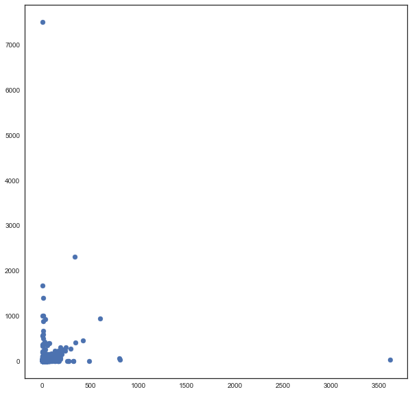

```python
plt.scatter(fare_preds, y_test)
```